# BEE552 Biometry Week 3 Lab

Maria Feiler

2/10/2022

We can ask many things about a statistical distribution:

1. Look at the probability density function: What is the probability of obtaining X (discrete) or a number in the interval (X1,X2) (continuous)?
2. Look at the cumulative probability: What is the probability of obtaining X < X*?
3. Look at the quantiles of the distributions: The inverse of the cumulative distribution - What is X* such that the cumulative probability of obtaining X < X* is the specified quantile? Quantiles can have any size: Quartiles, deciles, percentiles, etc.
4. Look at samples from the distribution: What does the distribution “look like?”

Four basic functions in R for these questions, and combining them with distribution calls means you can ask these questions about specific distributions.

- d = probability density function
- p = cumulative probability
- q = quantiles of the distribution
- r = random numbers generated from the distribution

For example:  
Normal distribution: dnorm, pnorm, qnorm, rnorm  
Log-normal distribution: dlnorm, plnorm, qlnorm, rlnorm  
Poisson: dpois, ppois, qpois, rpois

```r
# Take 100 random draws from the Standard Normal N(0,1)
data <- rnorm(100, mean = 0, sd = 1)
head(data)
```

```
## [1]  0.32374369  0.74541784  0.79009060  0.13376158  0.09713845 -1.18901084
```

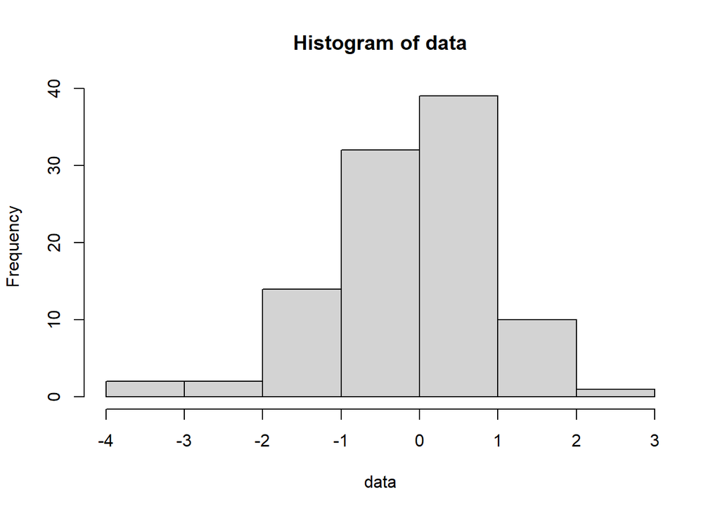

```r
# Make histogram
hist(data)
```

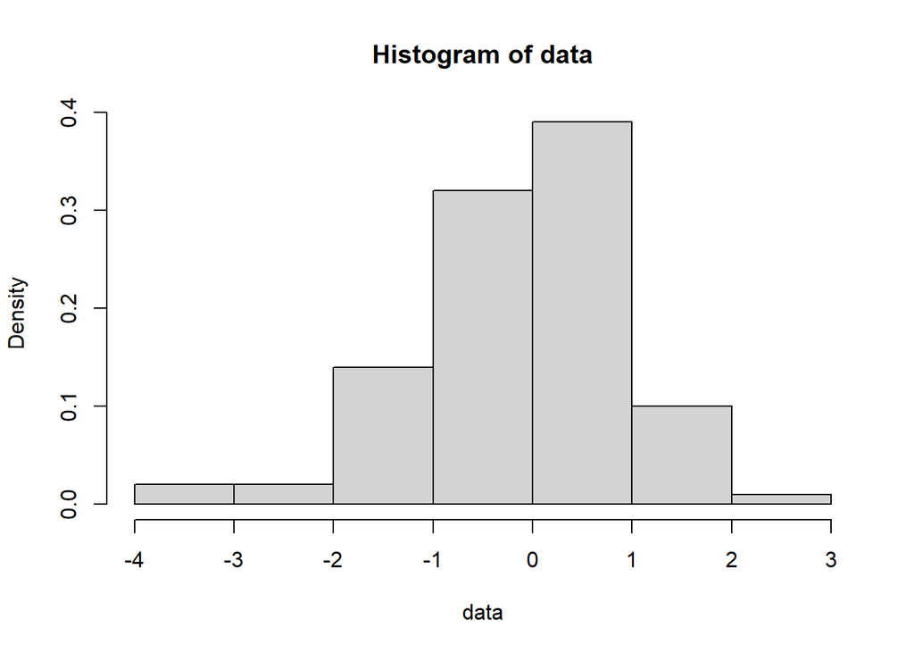

```r
# Make histogram using density
hist(data, freq = FALSE)
```

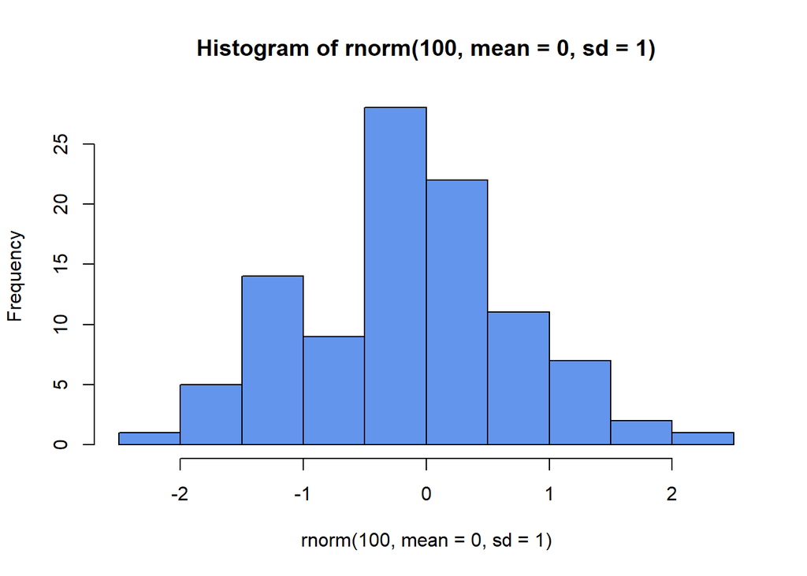

```r
hist(rnorm(100, mean = 0, sd = 1), col = "cornflowerblue")
```

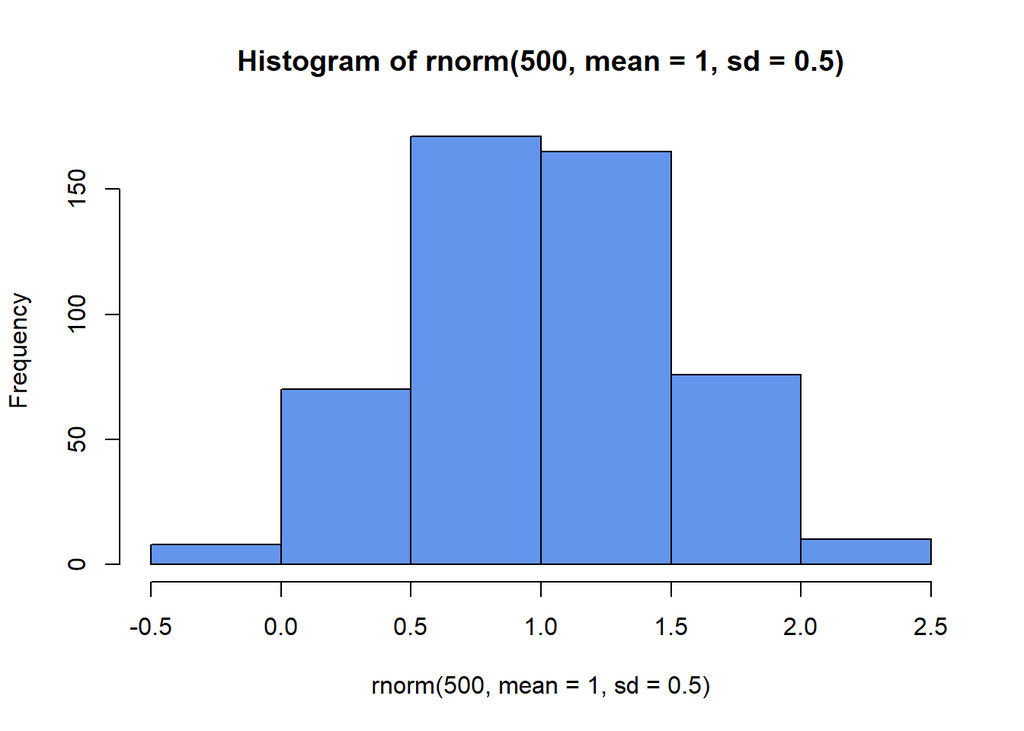

```r
hist(rnorm(500, mean = 1, sd = 0.5), col = "cornflowerblue")
```

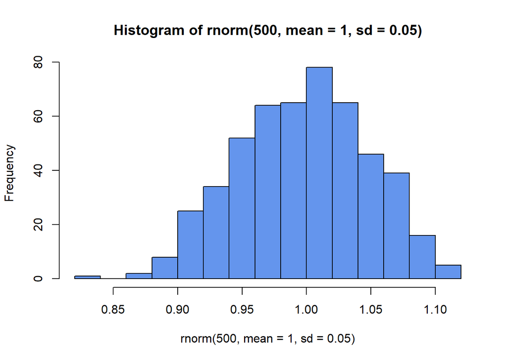

```r
hist(rnorm(500, mean = 1, sd = 0.05), col = "cornflowerblue")
```

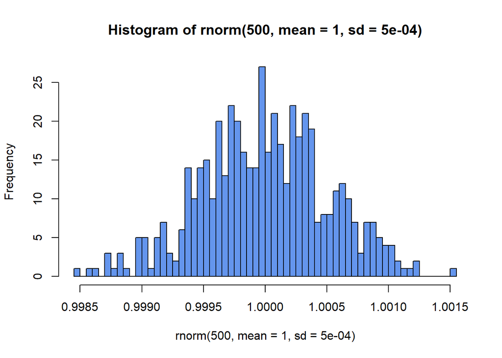

```r
hist(rnorm(500, mean = 1, sd = 0.0005), breaks = 100, col = "cornflowerblue")
```

```r
# What happens if you add the flag “plot=F?”
hist(rnorm(1000, mean = 0, sd = 1), plot = FALSE)
```

```
## $breaks
##  [1] -3.0 -2.5 -2.0 -1.5 -1.0 -0.5  0.0  0.5  1.0  1.5  2.0  2.5  3.0  3.5
##
## $counts
##  [1]   5  10  42  73 169 186 187 153 102  47  20   5   1
##
## $density
##  [1] 0.010 0.020 0.084 0.146 0.338 0.372 0.374 0.306 0.204 0.094 0.040 0.010
## [13] 0.002
##
## $mids
##  [1] -2.75 -2.25 -1.75 -1.25 -0.75 -0.25  0.25  0.75  1.25  1.75  2.25  2.75
## [13]  3.25
##
## $xname
## [1] "rnorm(1000, mean = 0, sd = 1)"
##
## $equidist
## [1] TRUE
##
## attr(,"class")
## [1] "histogram"
```

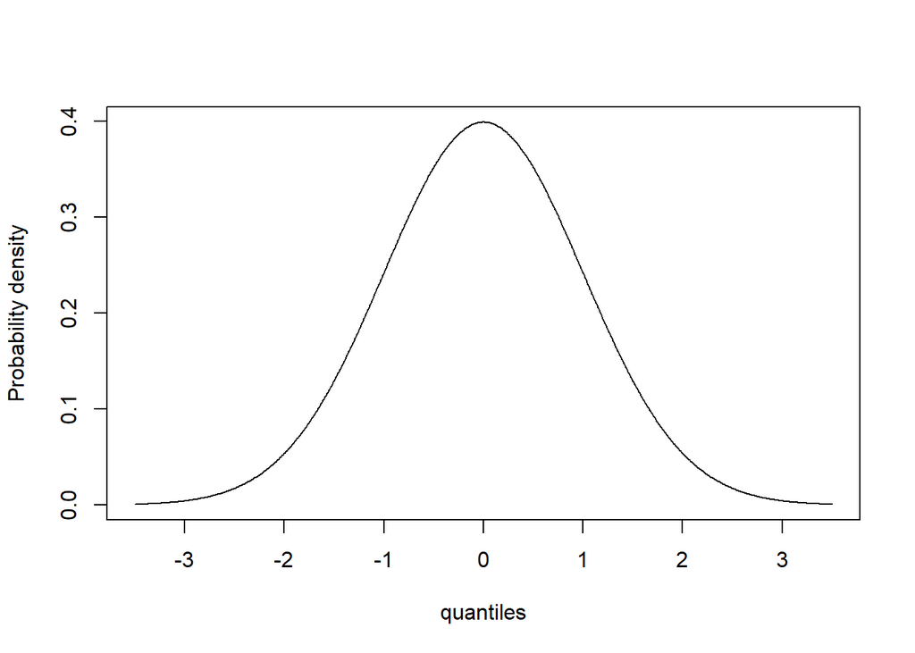

```r
quantiles <- seq(-3.5, 3.5, 0.01) # These are the quantiles

density <- dnorm(quantiles, mean = 0, sd = 1) # dnorm gives the pdf for a given quantile

plot(quantiles, density, type = "l", ylab = "Probability density")
```

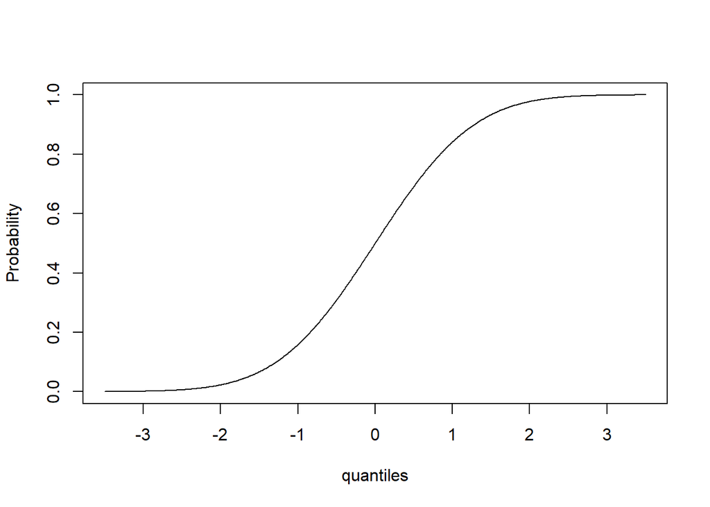

```r
cumulative <- pnorm(quantiles, mean = 0, sd = 1)
plot(quantiles, cumulative, type = "l", ylab = "Probability")
```

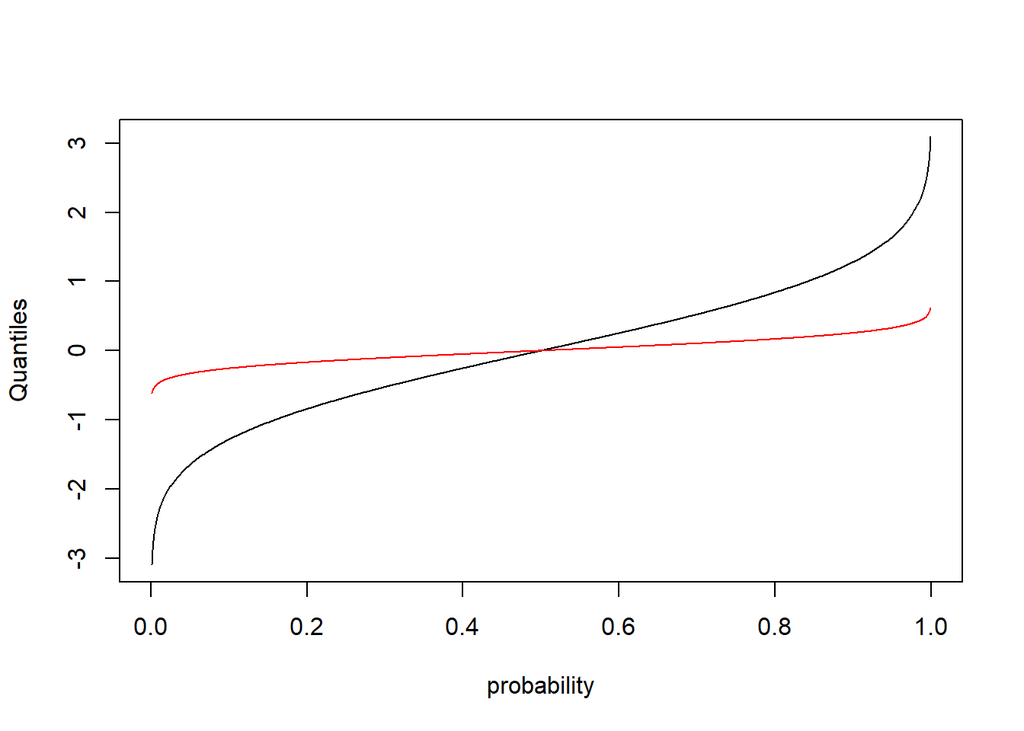

```r
probability <- seq(0, 1, 0.001)
quantiles <- qnorm(probability, mean = 0, sd = 1)
plot(probability, quantiles, type = "l", ylab = "Quantiles")

quantiles2 <- qnorm(probability, mean = 0, sd = 0.2)
plot(probability, quantiles, type = "l", ylab = "Quantiles")
lines(probability, quantiles2, col = "red")
```

```r
count<-rpois(500,lambda=3)
table(count)
```

```
## count
##   0   1   2   3   4   5   6   7   8   9
##  28  80 132 115  68  42  24   8   1   2
```

```r
mean(count)
```

```
## [1] 2.794
```

```r
sd(count)
```

```
## [1] 1.650762
```

*Checkpoint 1: Does everyone in your group understand the definition of a standard error?*  
Yes

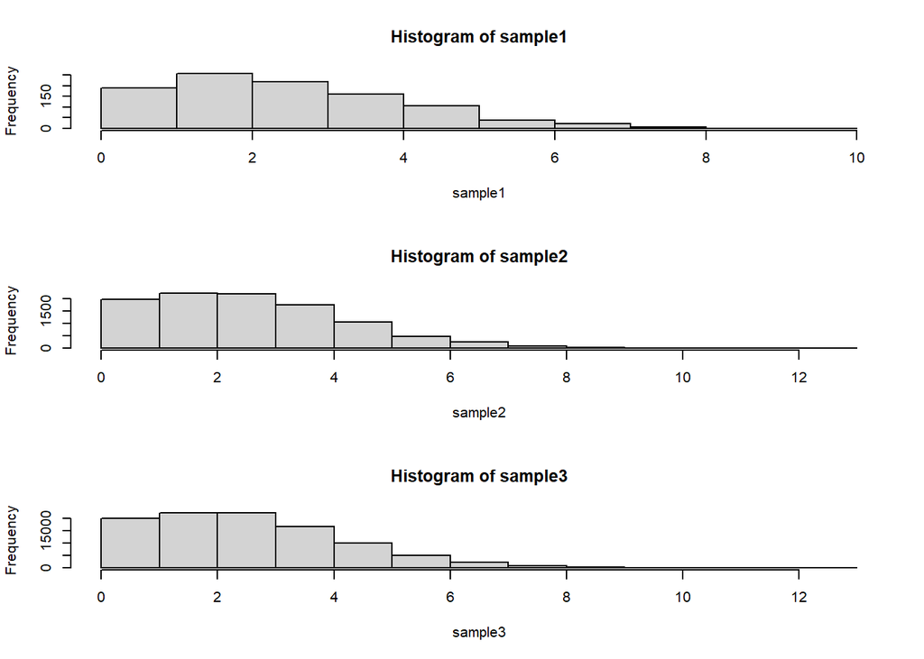

```r
par(mfrow = c(3, 1))  #Use ?par to see what this command does - more on this later

sample1 <- rpois(1000, lambda=3)
sample2 <- rpois(10000, lambda=3)
sample3 <- rpois(100000, lambda=3)

hist(sample1)
hist(sample2)
hist(sample3)
```

```r
sd(sample1)
```

```
## [1] 1.66858
```

```r
sd(sample2)
```

```
## [1] 1.738303
```

```r
sd(sample3)
```

```
## [1] 1.730868
```

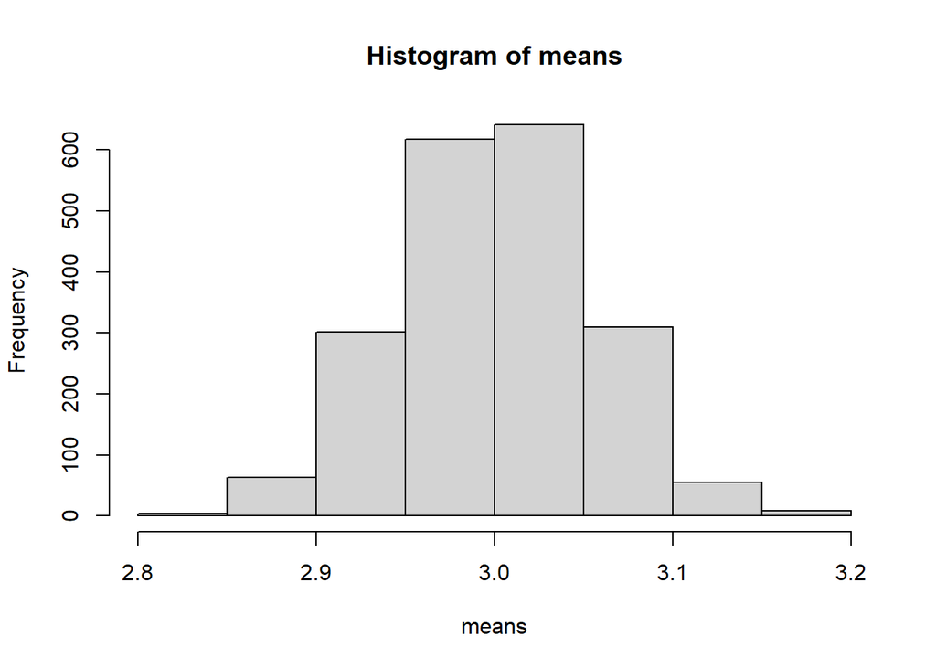

```r
par(mfrow = c(1, 1))
sample.size <- 1000
means <- c()

for (i in 1:2000) {
        means <- c(means, mean(rpois(sample.size, lambda = 3)))
}

hist(means)
```

```r
# Get sample standard errors
s.e.1 <- sqrt(var(rpois(sample.size, lambda = 3))/sample.size)
s.e.2 <- sd(means)

s.e.1
```

```
## [1] 0.05464263
```

```r
s.e.2
```

```
## [1] 0.05493634
```

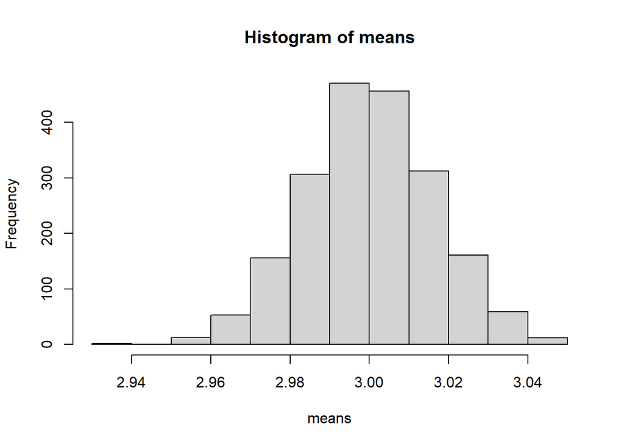

```r
par(mfrow = c(1, 1))
sample.size <- 10000
means <- c()

for (i in 1:2000) {
        means <- c(means, mean(rpois(sample.size, lambda = 3)))
}

hist(means)
```

```r
# Get sample standard errors
s.e.1 <- sqrt(var(rpois(sample.size, lambda = 3))/sample.size)
s.e.2 <- sd(means)

s.e.1
```

```
## [1] 0.01705059
```

```r
s.e.2
```

```
## [1] 0.01653954
```

*Checkpoint 2: How does increasing the sample size change the result?*  
It reduced the standard error because you are (in theory) better representing the population with teh larger sample size.

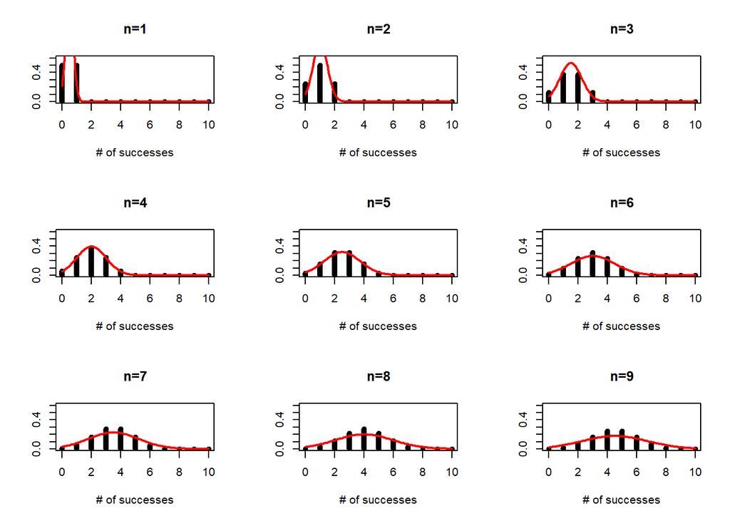

```r
par(mfrow=c(3,3))
p=0.5
plot(seq(0,10),dbinom(x=seq(0,10),size=1,prob=p),typ="h",lwd=5,xlab="# of successes",ylab="",main="n=1",ylim=c(0,0.6))
lines(seq(0,10,0.1),dnorm(seq(0,10,0.1),1*p,1*p*(1-p)),col="red",lwd=2)
plot(seq(0,10),dbinom(x=seq(0,10),size=2,prob=p),typ="h",lwd=5,xlab="# of successes",ylab="",main="n=2",ylim=c(0,0.6))
lines(seq(0,10,0.1),dnorm(seq(0,10,0.1),2*p,2*p*(1-p)),col="red",lwd=2)
plot(seq(0,10),dbinom(x=seq(0,10),size=3,prob=p),typ="h",lwd=5,xlab="# of successes",ylab="",main="n=3",ylim=c(0,0.6))
lines(seq(0,10,0.1),dnorm(seq(0,10,0.1),3*p,3*p*(1-p)),col="red",lwd=2)
plot(seq(0,10),dbinom(x=seq(0,10),size=4,prob=p),typ="h",lwd=5,xlab="# of successes",ylab="",main="n=4",ylim=c(0,0.6))
lines(seq(0,10,0.1),dnorm(seq(0,10,0.1),4*p,4*p*(1-p)),col="red",lwd=2)
plot(seq(0,10),dbinom(x=seq(0,10),size=5,prob=p),typ="h",lwd=5,xlab="# of successes",ylab="",main="n=5",ylim=c(0,0.6))
lines(seq(0,10,0.1),dnorm(seq(0,10,0.1),5*p,5*p*(1-p)),col="red",lwd=2)
plot(seq(0,10),dbinom(x=seq(0,10),size=6,prob=p),typ="h",lwd=5,xlab="# of successes",ylab="",main="n=6",ylim=c(0,0.6))
lines(seq(0,10,0.1),dnorm(seq(0,10,0.1),6*p,6*p*(1-p)),col="red",lwd=2)
plot(seq(0,10),dbinom(x=seq(0,10),size=7,prob=p),typ="h",lwd=5,xlab="# of successes",ylab="",main="n=7",ylim=c(0,0.6))
lines(seq(0,10,0.1),dnorm(seq(0,10,0.1),7*p,7*p*(1-p)),col="red",lwd=2)
plot(seq(0,10),dbinom(x=seq(0,10),size=8,prob=p),typ="h",lwd=5,xlab="# of successes",ylab="",main="n=8",ylim=c(0,0.6))
lines(seq(0,10,0.1),dnorm(seq(0,10,0.1),8*p,8*p*(1-p)),col="red",lwd=2)
plot(seq(0,10),dbinom(x=seq(0,10),size=9,prob=p),typ="h",lwd=5,xlab="# of successes",ylab="",main="n=9",ylim=c(0,0.6))
lines(seq(0,10,0.1),dnorm(seq(0,10,0.1),9*p,9*p*(1-p)),col="red",lwd=2)
```

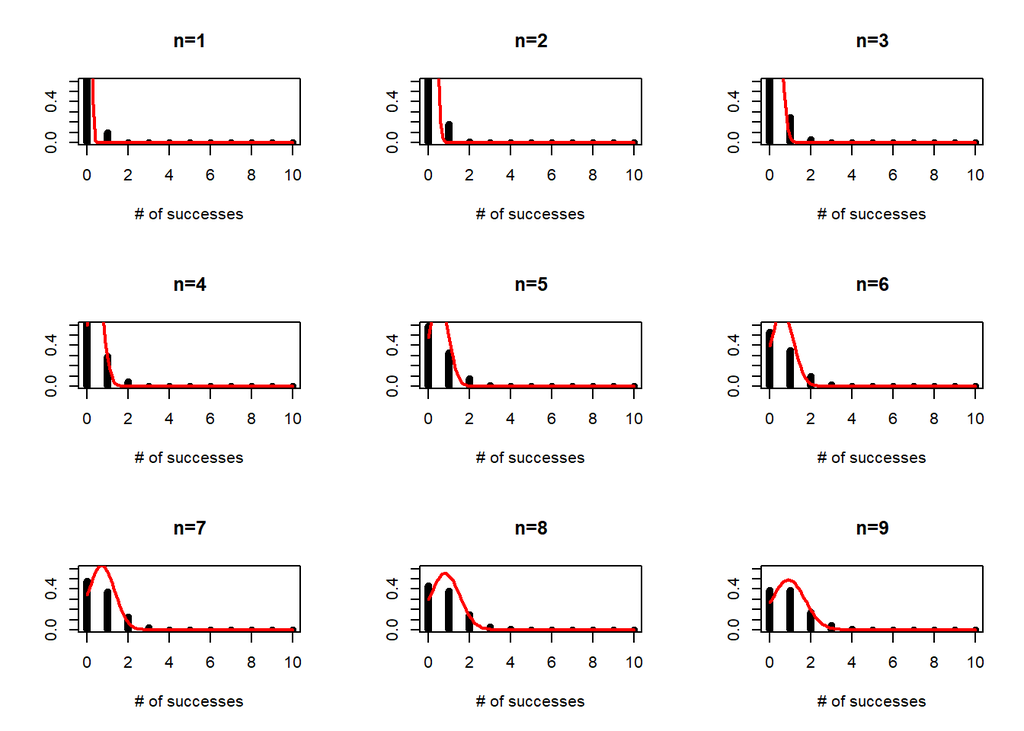

```r
par(mfrow=c(3,3))
p=0.1
plot(seq(0,10),dbinom(x=seq(0,10),size=1,prob=p),typ="h",lwd=5,xlab="# of successes",ylab="",main="n=1",ylim=c(0,0.6))
lines(seq(0,10,0.1),dnorm(seq(0,10,0.1),1*p,1*p*(1-p)),col="red",lwd=2)
plot(seq(0,10),dbinom(x=seq(0,10),size=2,prob=p),typ="h",lwd=5,xlab="# of successes",ylab="",main="n=2",ylim=c(0,0.6))
lines(seq(0,10,0.1),dnorm(seq(0,10,0.1),2*p,2*p*(1-p)),col="red",lwd=2)
plot(seq(0,10),dbinom(x=seq(0,10),size=3,prob=p),typ="h",lwd=5,xlab="# of successes",ylab="",main="n=3",ylim=c(0,0.6))
lines(seq(0,10,0.1),dnorm(seq(0,10,0.1),3*p,3*p*(1-p)),col="red",lwd=2)
plot(seq(0,10),dbinom(x=seq(0,10),size=4,prob=p),typ="h",lwd=5,xlab="# of successes",ylab="",main="n=4",ylim=c(0,0.6))
lines(seq(0,10,0.1),dnorm(seq(0,10,0.1),4*p,4*p*(1-p)),col="red",lwd=2)
plot(seq(0,10),dbinom(x=seq(0,10),size=5,prob=p),typ="h",lwd=5,xlab="# of successes",ylab="",main="n=5",ylim=c(0,0.6))
lines(seq(0,10,0.1),dnorm(seq(0,10,0.1),5*p,5*p*(1-p)),col="red",lwd=2)
plot(seq(0,10),dbinom(x=seq(0,10),size=6,prob=p),typ="h",lwd=5,xlab="# of successes",ylab="",main="n=6",ylim=c(0,0.6))
lines(seq(0,10,0.1),dnorm(seq(0,10,0.1),6*p,6*p*(1-p)),col="red",lwd=2)
plot(seq(0,10),dbinom(x=seq(0,10),size=7,prob=p),typ="h",lwd=5,xlab="# of successes",ylab="",main="n=7",ylim=c(0,0.6))
lines(seq(0,10,0.1),dnorm(seq(0,10,0.1),7*p,7*p*(1-p)),col="red",lwd=2)
plot(seq(0,10),dbinom(x=seq(0,10),size=8,prob=p),typ="h",lwd=5,xlab="# of successes",ylab="",main="n=8",ylim=c(0,0.6))
lines(seq(0,10,0.1),dnorm(seq(0,10,0.1),8*p,8*p*(1-p)),col="red",lwd=2)
plot(seq(0,10),dbinom(x=seq(0,10),size=9,prob=p),typ="h",lwd=5,xlab="# of successes",ylab="",main="n=9",ylim=c(0,0.6))
lines(seq(0,10,0.1),dnorm(seq(0,10,0.1),9*p,9*p*(1-p)),col="red",lwd=2)
```

```r
library(MASS) #this loads the library into the workspace
sample.pois<-rpois(1000,lambda=20)
fit<-fitdistr(sample.pois,"gamma",start=list(shape=20,scale=1))
fit
```

```
##       shape         scale
##   19.78579318    1.01456737
##  ( 0.87743644) ( 0.04556712)
```

```r
names(fit)
```

```
## [1] "estimate" "sd"       "vcov"     "loglik"   "n"
```

```r
fit$estimate
```

```
##     shape     scale
## 19.785793  1.014567
```

```r
fit$estimate[1]
```

```
##    shape
## 19.78579
```

```r
fit$estimate[2]
```

```
##    scale
## 1.014567
```

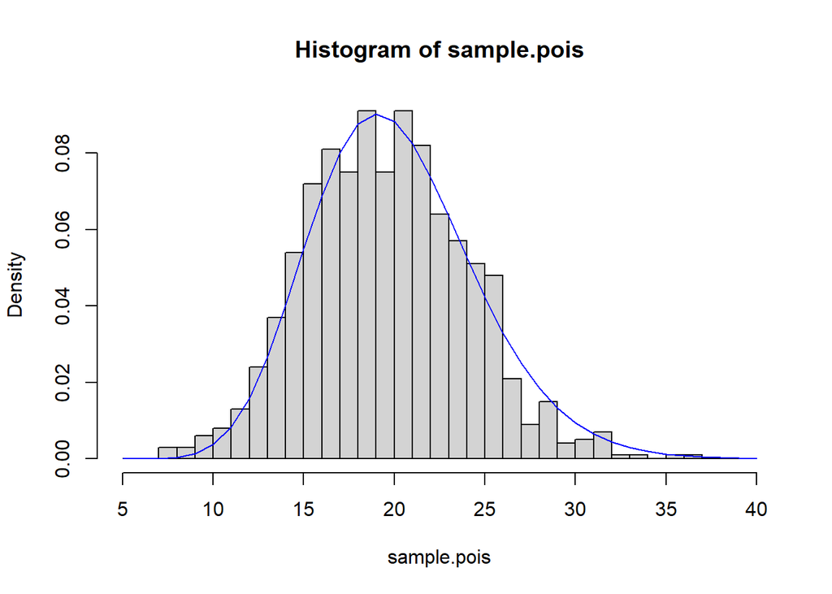

```r
x.vals <-  seq(from = 5, to = 40, by = 1)
hist(sample.pois, freq = FALSE, breaks = x.vals)
lines(x.vals, dgamma(x.vals,
                     shape = fit$estimate[1],
                     scale = fit$estimate[2]),
                     col = "blue")
```

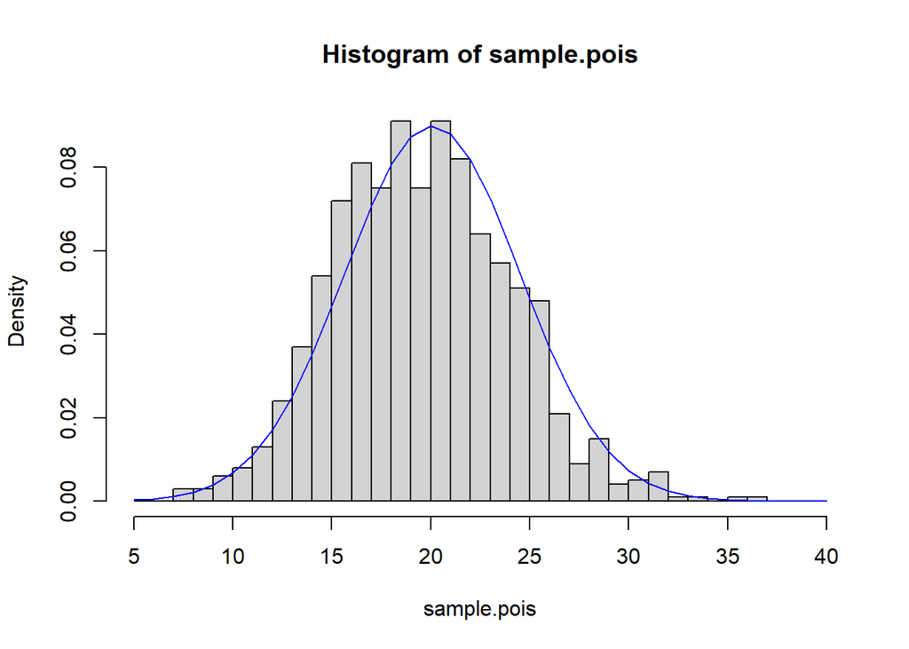

```r
fit2<-fitdistr(sample.pois,"normal")

hist(sample.pois, freq = FALSE, breaks = x.vals)
lines(x.vals, dnorm(x.vals,
                     mean = fit2$estimate[1],
                     sd = fit2$estimate[2]),
                     col = "blue")
```

*Checkpoint 3: We see here that the data, which were generated by a Poisson distribution, are fit quite well by the Normal distribution. If this data were research data, what would be one major clue that the Poisson distribution was more appropriate than the Normal distribution?* We would prefer the Poisson because our data is discrete, so any predictions we’d make based off this distribution would also be discrete (17 seeds vs 17.3 seeds).

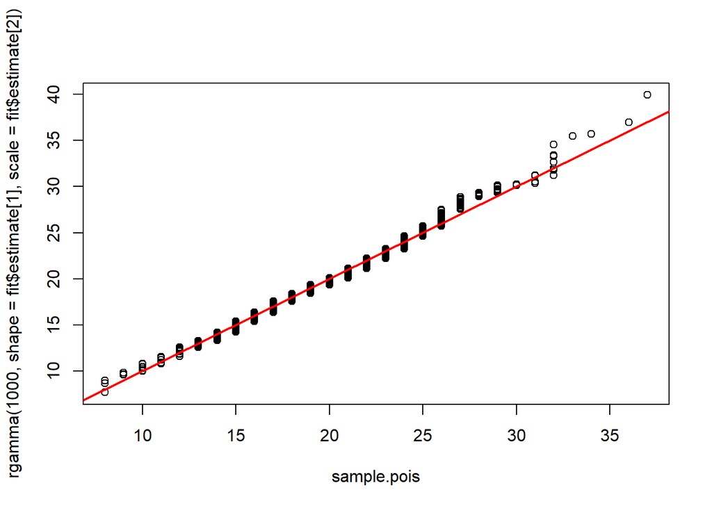

```r
qqplot(x = sample.pois,
       y = rgamma(1000,
                  shape = fit$estimate[1],
                  scale = fit$estimate[2])
       )

abline(a = 0, b = 1, col = "red", lwd = 2)
```

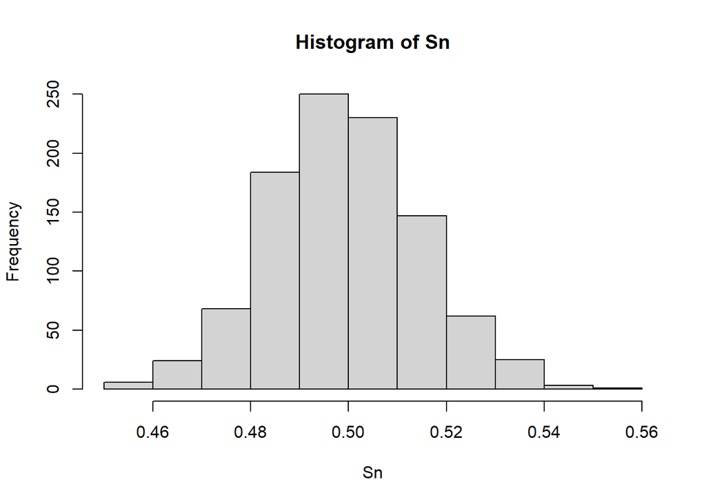

```r
 bern <- matrix(0, nrow = 1000, ncol = 1000)

for (i in 1:1000){
        bern[i,] <- rbinom(n = 1000,
                           size = 1,
                           prob = 0.5)
}

Sn <- rowMeans(bern)

hist(Sn)
```